# Identifying Effective Learning Activities in an Online Course

Charlie Guthrie  
May 2, 2016

APSTA-GE 2017: Educational Data Science Practicum

### Goal

Identify which learning activities were most effective at increasing student assessment performance.

[figure not shown]

23-card online course

Learning activities on cards include:

- reading material
- links
- images
- assessments throughout

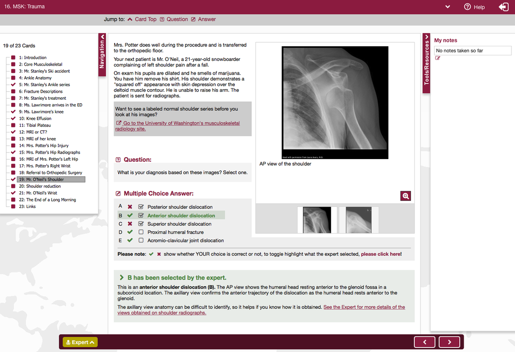

### Key Variables

Assessment cards

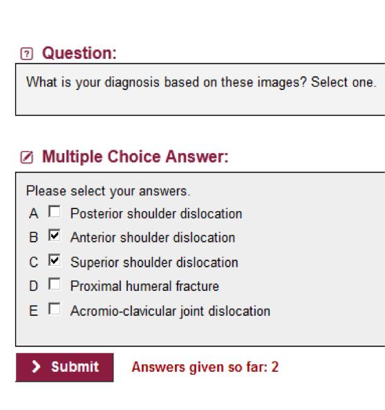

### Key Variables

Variables that may have an impact on student performance:

- **Clicking hyperlinks**
- Magnifying images
- Checking answers using “expert” links
- Time spent on cards

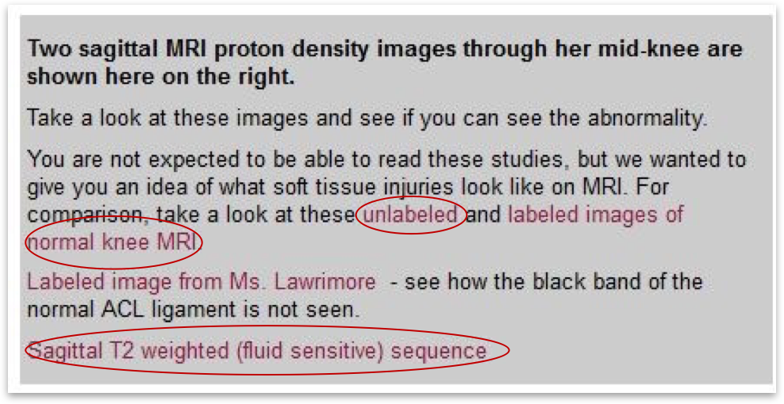

### Key Variables

Variables that may have an impact on student performance:

- Clicking hyperlinks
- **Magnifying images**
- Checking answers using “expert” links
- Time spent on cards

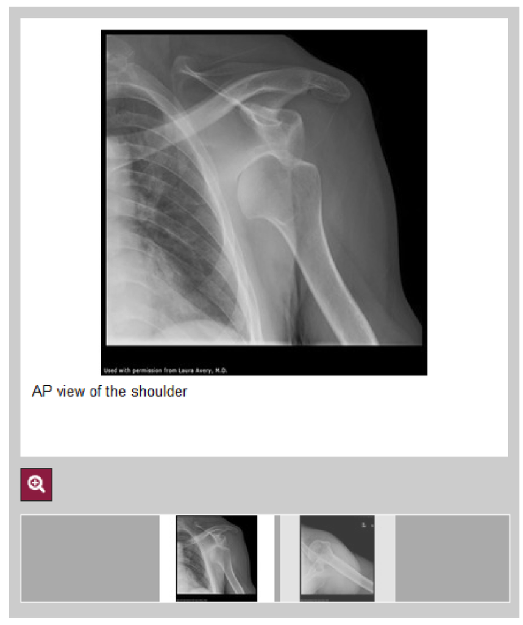

### Key Variables

Variables that may have an impact on student performance:

- Clicking hyperlinks
- Magnifying images
- **Checking answers using “expert” links**
- Time spent on cards

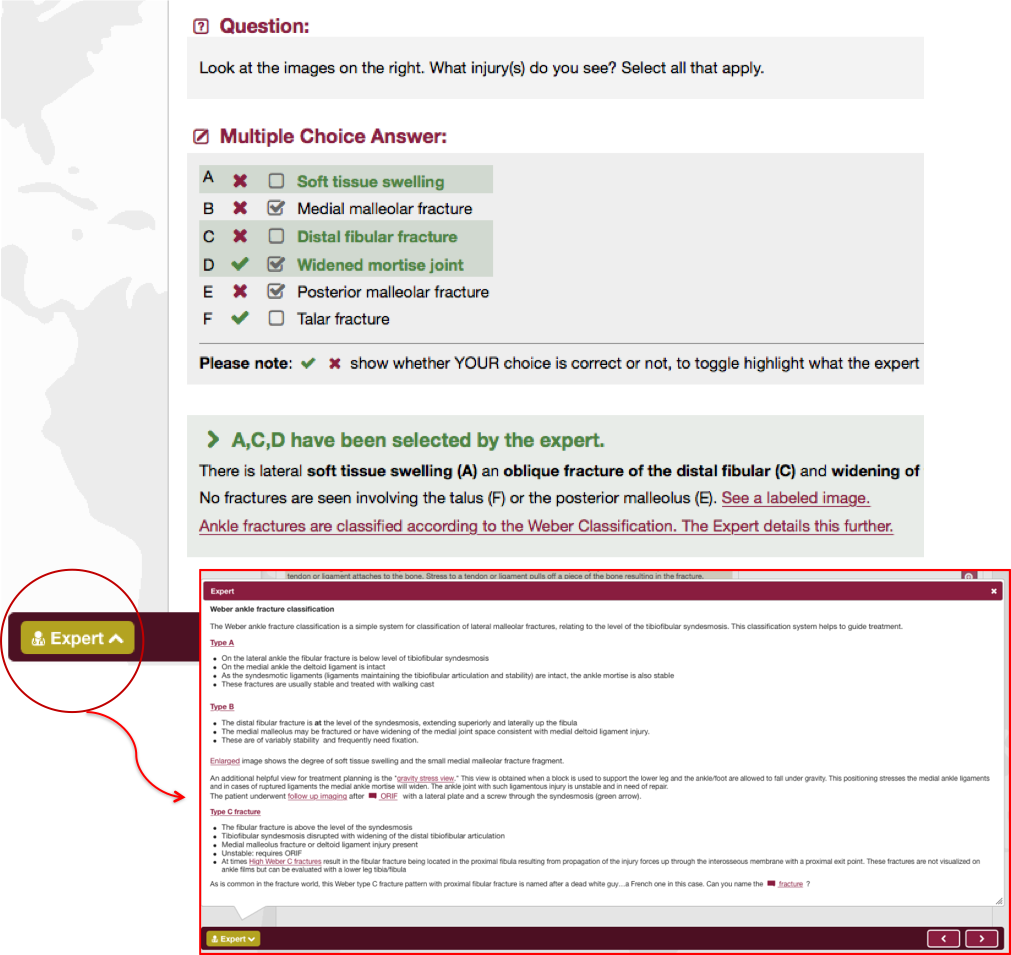

### Key Variables

Variables that may have an impact on student performance:

- Clicking hyperlinks
- Magnifying images
- Checking answers using “expert” links
- **Time spent on cards**

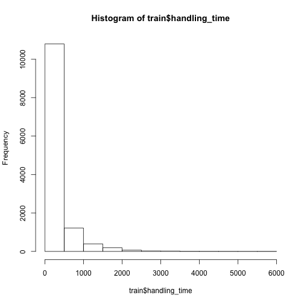

### Key Variables

Not all activities are present on all cards.

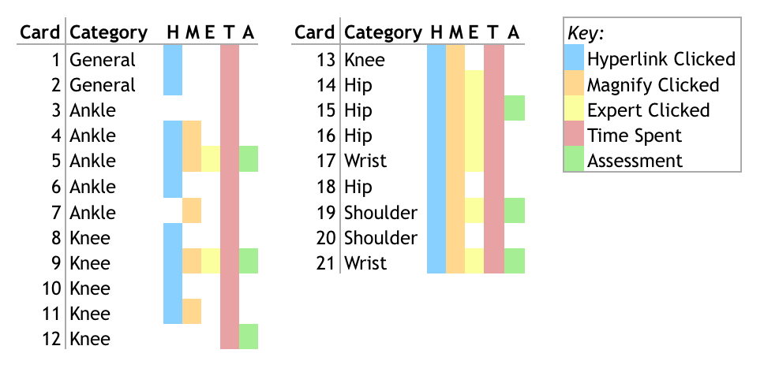

### Project Overview

### Investigation 1

Predict student performance from overall activity engagement.

### Investigation 2

Measure impact of specific learning activities and cards.

### Investigation 1: Does Studying Work?

Is there a relationship between student engagement and performance?

### Investigation 1: Does Studying Work?

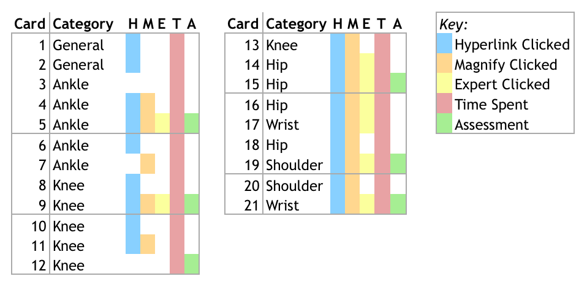

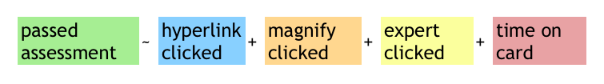

### Investigation 1: Procedure

1. Restructure data: 1 line per student per assessment
   - assessments are aggregated together
2. Data transformations
   - converting clicks to binary
   - log-transform and binary transform of handling_time
3. Model predicts if student will pass any assessment given relevant material

```
Call:
glm(formula = label ~ hyperlink_clicked + magnify_clicked + expert_clicked +
    time_lt_20 + time_gt_100, family = "binomial", data = train)

Deviance Residuals:
    Min       1Q   Median       3Q      Max
-1.5531  -1.2584   0.9018   1.0558   1.3168

Coefficients:
                  Estimate Std. Error z value Pr(>|z|)
(Intercept)        0.02177    0.03803   0.573   0.5670
hyperlink_clicked  0.16673    0.04287   3.889   0.0001 ***
magnify_clicked    0.22979    0.04387   5.238 1.63e-07 ***
expert_clicked     0.16077    0.07190   2.236   0.0254 *
time_lt_20        -0.34354    0.06048  -5.680 1.35e-08 ***
time_gt_100        0.27130    0.04483   6.052 1.43e-09 ***
---
Signif. codes:  0 '***' 0.001 '**' 0.01 '*' 0.05 '.' 0.1 ' ' 1

(Dispersion parameter for binomial family taken to be 1)

    Null deviance: 17355  on 12708  degrees of freedom
Residual deviance: 17003  on 12703  degrees of freedom
AIC: 17015

Number of Fisher Scoring iterations: 4
```

### Investigation 1: Results

|  | Model Type | Activity Measure | Time Spent | AUC |
| --- | --- | --- | --- | --- |
| 1 | logistic | scalar | scalar | 0.588 |
| 2 | logistic | scalar | log-transformed | 0.589 |
| 3 | logistic | binary | log-transformed | 0.593 |
| 4 | logistic | binary | binary | 0.594 |
| 5 | tree | scalar | scalar | 0.592 |
| 6 | tree | scalar | log-transformed | 0.597 |
| 7 | tree | binary | log-transformed | 0.596 |
| 8 | tree | binary | binary | 0.594 |

```
[1] "auc on test of model 4 = 0.61"
```

### Investigation 2

Which specific learning activities helped assessment score?

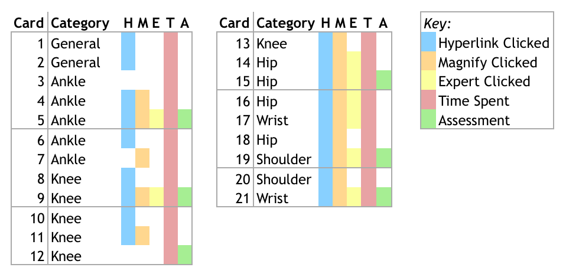

### Investigation 2: Procedure

Which activities help students answer the question on card 5?

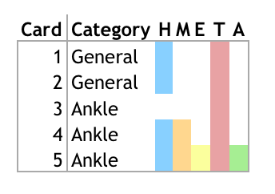

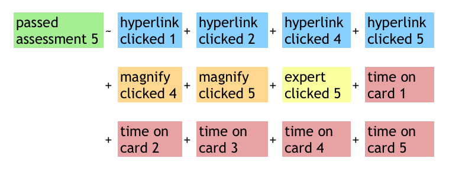

### Investigation 2: Procedure

1. Run lasso-regularized logistic regression using all activities before assessment card
2. Find largest regularization parameter that is close to maximum cross-validation AUC
3. Re-run logistic with remaining variables
4. Return variables that have significant impact with p-value < 0.05

### Investigation 2: Results

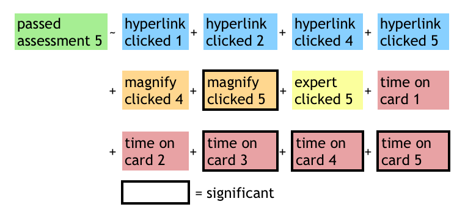

### Investigation 2: Results

What activities contributed to performance on each assessment card?

| Card | AUC | Significant Variables |
| --- | --- | --- |
| 5 | 0.631 | (Intercept), magnify_clicked_5, time_lt_20_3, time_lt_20_4, time_lt_20_5 |
| 9 | 0.626 | (Intercept), label_5, magnify_clicked_9, time_lt_20_5, time_lt_20_7 |
| 12 | 0.648 | label_5, label_9, hyperlink_clicked_10, time_lt_20_5, time_lt_20_9, time_lt_20_12 |
| 15 | 0.563 | (Intercept), time_lt_20_5, time_gt_100_15 |
| 19 | 0.616 | label_5, label_12, label_15, hyperlink_clicked_18, magnify_clicked_19, time_lt_20_2, time_lt_20_15, time_lt_20_19, time_gt_100_19 |
| 21 | 0.628 | label_5, label_9, label_19, hyperlink_clicked_21, magnify_clicked_20, expert_clicked_19, time_lt_20_15, time_lt_20_20, time_gt_100_21 |

### Investigation 2: Results

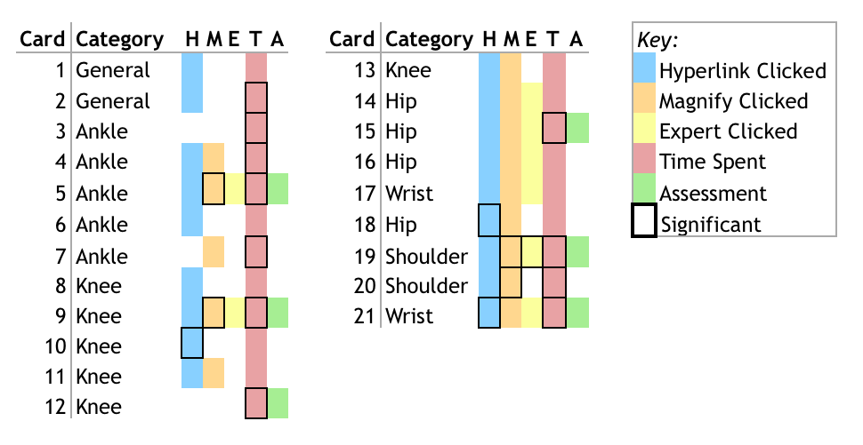

### Next Steps

- Close analysis of card content
- Discussion with MedU content designers
- Make re-usable for any online course.
- Use more robust, summative assessment.

### Thanks

To Matt Cirigliano, Martin Pusic, and Oleksandr Savenkov of NYU School of Medicine for providing data and consultation.